# IBM Data Science Project

### Week five:IBM Courseral Data Science Capstone Project: Analysis of USA Weather Anomalies

#### Data Description

More than 3 million records of historical US data temperature outliers by date and latitude/longtitude coordinates. Temperature outliers from 1964-2013. Reporting station ID, name, min/max temperature, as well as degree coordinates of the recorded weather. Original weather data collected from NOAA. Each entry represents a report from a weather station with high or low temperatures that were historical outliers within that month, averaged over time. Note: This table's columns contain data that was collected from NOAA as well as data that was calculated using Enigma's assortment of weather data. The direct source of the information is identified in the description of the column.

The data set has 10 features:date_str,the date when temperatures where recorded;degrees_from_mean,which is the outlier temperature/anomalies;id, the unique identification of each temperature series;longitude and latitude, which are the gerographical coordinates;max_temp and min_temp, the maximum and minimum temperatures recorded;station_name, the name of the station;type, which is the weather classification type, and serialid, the cummulative identification for each temperature.

Data source:The original data set can be accessed from https://data.world/carlvlewis/u-s-weather-outliers-1964/file/weather-anomalies-1964-2013.csv

#### Hypothesis testing/Inferential Statistics

Realtionships are tested using both Regression analysis and Analyisis of Variance (ANOVA).

#### Machine Learning/Prediction

Supervised Regression and Support Vector Machine techiniques are used for prediction

#### Loading dependencies and packages

```python
import numpy as np
import pandas as pd
import types
from botocore.client import Config
import ibm_boto3
import matplotlib.pyplot as plt
import seaborn as sns
from statsmodels.tsa.arima_model import ARIMA
from sklearn.metrics import mean_squared_error
%matplotlib inline
sns.set()
```

#### loading data from file into pandas

```python
file_path ='C://Users//KizitoB//Desktop//us_weather_anomalies.xlsx'
import types
import pandas as pd
from botocore.client import Config
import ibm_boto3

def __iter__(self): return 0

# @hidden_cell
# The following code accesses a file in your IBM Cloud Object Storage. It includes your credentials.
# You might want to remove those credentials before you share the notebook.
client_18e7e7257f2343d5819b75b03d91d72a = ibm_boto3.client(service_name='s3',
    ibm_api_key_id='qzIv_ApnrgGG5Qp1gC0z9b1BQf_Wexapp98xk5Y0VYKc',
    ibm_auth_endpoint="https://iam.eu-gb.bluemix.net/oidc/token",
    config=Config(signature_version='oauth'),
    endpoint_url='https://s3.eu-geo.objectstorage.service.networklayer.com')

body = client_18e7e7257f2343d5819b75b03d91d72a.get_object(Bucket='ibmdatasciencefinalproject-donotdelete-pr-odjyjl3yzaz1ag',Key='us_weather_anomalies.xlsx')['Body']
# add missing __iter__ method, so pandas accepts body as file-like object
if not hasattr(body, "__iter__"): body.__iter__ = types.MethodType( __iter__, body )

df = pd.read_excel(body)
df.head()
print(file_path)
```

Reading the first five rows

```python
df.head()
```

|  | date_str | degrees_from_mean | id | longitude | latitude | max_temp | min_temp | station_name | type | serialid |
| --- | --- | --- | --- | --- | --- | --- | --- | --- | --- | --- |
| 0 | 2013-12-31 | -26.16 | USC00202094 | -83.9014 | 45.9983 | -12.2 | -22.8 | DETOUR VILLAGE | Strong Cold | 1013066 |
| 1 | 2013-12-31 | -15.28 | USW00014897 | -89.6256 | 44.9258 | -18.2 | -26.0 | WAUSAU DWTN AP | Weak Cold | 1013067 |
| 2 | 2013-12-31 | -32.28 | USC00218419 | -91.6653 | 47.0258 | -17.8 | -27.8 | TWO HARBORS | Strong Cold | 1013068 |
| 3 | 2013-12-31 | -32.47 | USC00476200 | -88.5036 | 43.1003 | -17.2 | -24.4 | OCONOMOWOC | Strong Cold | 1013069 |
| 4 | 2013-12-31 | -31.52 | USC00204104 | -90.1892 | 46.4656 | -19.4 | -29.4 | IRONWOOD | Strong Cold | 1013070 |

Reading the last five rows

```python
df.tail()
```

|  | date_str | degrees_from_mean | id | longitude | latitude | max_temp | min_temp | station_name | type | serialid |
| --- | --- | --- | --- | --- | --- | --- | --- | --- | --- | --- |
| 1048570 | 1964-01-01 | 13.89 | USC00248021 | -111.7406 | 47.4775 | 15.6 | 3.3 | SUN RIVER 4 S | Weak Hot | 94880 |
| 1048571 | 1964-01-01 | 8.83 | USC00248211 | -115.3594 | 47.5933 | 10.6 | -3.9 | THOMPSON FALLS PH | Weak Hot | 94881 |
| 1048572 | 1964-01-01 | 14.24 | USW00014912 | -98.8681 | 48.1069 | 5.0 | 0.0 | DEVILS LAKE KDLR | Weak Hot | 94882 |
| 1048573 | 1964-01-01 | 34.11 | USC00322525 | -98.4714 | 48.4239 | 3.9 | -2.2 | EDMORE 1NW | Strong Hot | 94883 |
| 1048574 | 1964-01-01 | 14.72 | USC00252205 | -97.1328 | 41.2492 | 14.4 | -4.4 | DAVID CITY | Weak Hot | 94884 |

Data Description

```python
df.info()
```

```
<class 'pandas.core.frame.DataFrame'>
RangeIndex: 1048575 entries, 0 to 1048574
Data columns (total 10 columns):
date_str             1048575 non-null datetime64[ns]
degrees_from_mean    1048575 non-null float64
id                   1048575 non-null object
longitude            1048575 non-null float64
latitude             1048575 non-null float64
max_temp             1048575 non-null float64
min_temp             1048575 non-null float64
station_name         1048575 non-null object
type                 1048575 non-null object
serialid             1048575 non-null int64
dtypes: datetime64[ns](1), float64(5), int64(1), object(3)
memory usage: 80.0+ MB
```

#### Data Preparation and Wrangling

```python
weather_category_numeric = [] # creating numeric categories for weather_category feature. Preparing it for statistical analysis
for value in df['type']:
    if value == 'Weak Hot':
        weather_category_numeric.append(1)
    elif value == 'Weak Cold':
        weather_category_numeric.append(2)
    elif value == 'Strong Cold':
        weather_category_numeric.append(3)
    elif value == 'Strong Hot':
        weather_category_numeric.append(4)

df['weather_category_numeric'] = weather_category_numeric

df['average_temp'] = (df['max_temp'] + df['min_temp'])/2 # Creating pooled  value for both the min and max temperatures
```

```python
df = df.rename(columns={'date_str':'period','degrees_from_mean':'weather_anomalies','type':'weather_category'})# Renaming features
```

```python
df.head()
```

|  | period | weather_anomalies | id | longitude | latitude | max_temp | min_temp | station_name | weather_category | serialid | weather_category_numeric | average_temp |
| --- | --- | --- | --- | --- | --- | --- | --- | --- | --- | --- | --- | --- |
| 0 | 2013-12-31 | -26.16 | USC00202094 | -83.9014 | 45.9983 | -12.2 | -22.8 | DETOUR VILLAGE | Strong Cold | 1013066 | 3 | -17.5 |
| 1 | 2013-12-31 | -15.28 | USW00014897 | -89.6256 | 44.9258 | -18.2 | -26.0 | WAUSAU DWTN AP | Weak Cold | 1013067 | 2 | -22.1 |
| 2 | 2013-12-31 | -32.28 | USC00218419 | -91.6653 | 47.0258 | -17.8 | -27.8 | TWO HARBORS | Strong Cold | 1013068 | 3 | -22.8 |
| 3 | 2013-12-31 | -32.47 | USC00476200 | -88.5036 | 43.1003 | -17.2 | -24.4 | OCONOMOWOC | Strong Cold | 1013069 | 3 | -20.8 |
| 4 | 2013-12-31 | -31.52 | USC00204104 | -90.1892 | 46.4656 | -19.4 | -29.4 | IRONWOOD | Strong Cold | 1013070 | 3 | -24.4 |

#### Exploratory Data Analysis

Distribution of Weather Caterogies using a histogram

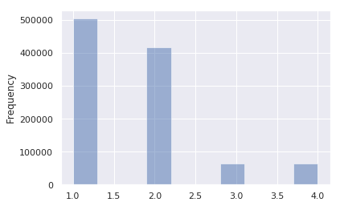

```python
df['weather_category_numeric'].plot.hist(bins =10 , alpha = 0.5)
```

Correlation Analysis between weather_anomalies,max_temp,min_temp,weather_category_numeric

```python
df[['weather_anomalies','max_temp','min_temp','weather_category_numeric']].corr()
```

|  | weather_anomalies | max_temp | min_temp | weather_category_numeric |
| --- | --- | --- | --- | --- |
| weather_anomalies | 1.000000 | 0.657813 | 0.626564 | -0.324860 |
| max_temp | 0.657813 | 1.000000 | 0.884731 | -0.335496 |
| min_temp | 0.626564 | 0.884731 | 1.000000 | -0.304538 |
| weather_category_numeric | -0.324860 | -0.335496 | -0.304538 | 1.000000 |

```python
df.groupby('weather_category_numeric').corr()
```

| weather_category_numeric |  | weather_anomalies | longitude | latitude | max_temp | min_temp | serialid | average_temp |
| --- | --- | --- | --- | --- | --- | --- | --- | --- |
| 1 | weather_anomalies | 1.000000 | 0.086573 | 0.347204 | -0.437077 | -0.537684 | 0.009624 | -0.527322 |
|  | longitude | 0.086573 | 1.000000 | -0.328513 | 0.092672 | 0.210796 | -0.028889 | 0.163361 |
|  | latitude | 0.347204 | -0.328513 | 1.000000 | -0.356912 | -0.424774 | -0.003995 | -0.422993 |
|  | max_temp | -0.437077 | 0.092672 | -0.356912 | 1.000000 | 0.702363 | -0.009268 | 0.925340 |
|  | min_temp | -0.537684 | 0.210796 | -0.424774 | 0.702363 | 1.000000 | 0.005400 | 0.919803 |
|  | serialid | 0.009624 | -0.028889 | -0.003995 | -0.009268 | 0.005400 | 1.000000 | -0.002233 |
|  | average_temp | -0.527322 | 0.163361 | -0.422993 | 0.925340 | 0.919803 | -0.002233 | 1.000000 |
| 2 | weather_anomalies | 1.000000 | -0.063827 | -0.252869 | 0.704789 | 0.651183 | -0.024015 | 0.706148 |
|  | longitude | -0.063827 | 1.000000 | -0.299828 | 0.042078 | 0.073516 | 0.014184 | 0.060332 |
|  | latitude | -0.252869 | -0.299828 | 1.000000 | -0.408324 | -0.408511 | -0.015304 | -0.425504 |
|  | max_temp | 0.704789 | 0.042078 | -0.408324 | 1.000000 | 0.842599 | 0.003383 | 0.959253 |
|  | min_temp | 0.651183 | 0.073516 | -0.408511 | 0.842599 | 1.000000 | 0.048947 | 0.960430 |
|  | serialid | -0.024015 | 0.014184 | -0.015304 | 0.003383 | 0.048947 | 1.000000 | 0.027430 |
|  | average_temp | 0.706148 | 0.060332 | -0.425504 | 0.959253 | 0.960430 | 0.027430 | 1.000000 |
| 3 | weather_anomalies | 1.000000 | 0.098840 | -0.346606 | 0.796486 | 0.798123 | 0.088198 | 0.806335 |
|  | longitude | 0.098840 | 1.000000 | -0.472576 | 0.151127 | 0.158895 | 0.005946 | 0.156783 |
|  | latitude | -0.346606 | -0.472576 | 1.000000 | -0.523315 | -0.485997 | -0.043129 | -0.510291 |
|  | max_temp | 0.796486 | 0.151127 | -0.523315 | 1.000000 | 0.955468 | 0.120860 | 0.988710 |
|  | min_temp | 0.798123 | 0.158895 | -0.485997 | 0.955468 | 1.000000 | 0.114578 | 0.988899 |
|  | serialid | 0.088198 | 0.005946 | -0.043129 | 0.120860 | 0.114578 | 1.000000 | 0.119039 |
|  | average_temp | 0.806335 | 0.156783 | -0.510291 | 0.988710 | 0.988899 | 0.119039 | 1.000000 |
| 4 | weather_anomalies | 1.000000 | 0.177591 | 0.270021 | -0.562532 | -0.545876 | 0.040044 | -0.573845 |
|  | longitude | 0.177591 | 1.000000 | -0.379156 | 0.013691 | 0.147328 | -0.022417 | 0.076466 |
|  | latitude | 0.270021 | -0.379156 | 1.000000 | -0.354177 | -0.440024 | -0.061915 | -0.406217 |
|  | max_temp | -0.562532 | 0.013691 | -0.354177 | 1.000000 | 0.869686 | 0.007600 | 0.973155 |
|  | min_temp | -0.545876 | 0.147328 | -0.440024 | 0.869686 | 1.000000 | 0.014105 | 0.959944 |
|  | serialid | 0.040044 | -0.022417 | -0.061915 | 0.007600 | 0.014105 | 1.000000 | 0.010891 |
|  | average_temp | -0.573845 | 0.076466 | -0.406217 | 0.973155 | 0.959944 | 0.010891 | 1.000000 |

#### Exploratory Visual Time serie Analysis

```python
df['period'] = pd.to_datetime(df.period)
df.set_index('period',inplace =True)
```

```python
df.head()
```

| period | weather_anomalies | id | longitude | latitude | max_temp | min_temp | station_name | weather_category | serialid | weather_category_numeric | average_temp |
| --- | --- | --- | --- | --- | --- | --- | --- | --- | --- | --- | --- |
| 2013-12-31 | -26.16 | USC00202094 | -83.9014 | 45.9983 | -12.2 | -22.8 | DETOUR VILLAGE | Strong Cold | 1013066 | 3 | -17.5 |
| 2013-12-31 | -15.28 | USW00014897 | -89.6256 | 44.9258 | -18.2 | -26.0 | WAUSAU DWTN AP | Weak Cold | 1013067 | 2 | -22.1 |
| 2013-12-31 | -32.28 | USC00218419 | -91.6653 | 47.0258 | -17.8 | -27.8 | TWO HARBORS | Strong Cold | 1013068 | 3 | -22.8 |
| 2013-12-31 | -32.47 | USC00476200 | -88.5036 | 43.1003 | -17.2 | -24.4 | OCONOMOWOC | Strong Cold | 1013069 | 3 | -20.8 |
| 2013-12-31 | -31.52 | USC00204104 | -90.1892 | 46.4656 | -19.4 | -29.4 | IRONWOOD | Strong Cold | 1013070 | 3 | -24.4 |

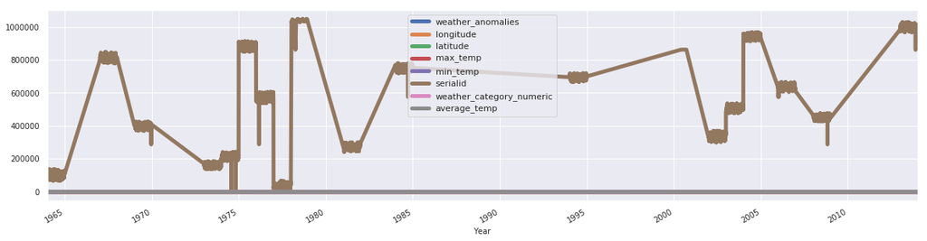

```python
df.plot(figsize=(20,5), linewidth = 5, fontsize = 10 )
plt.xlabel('Year',fontsize = 10 )
```

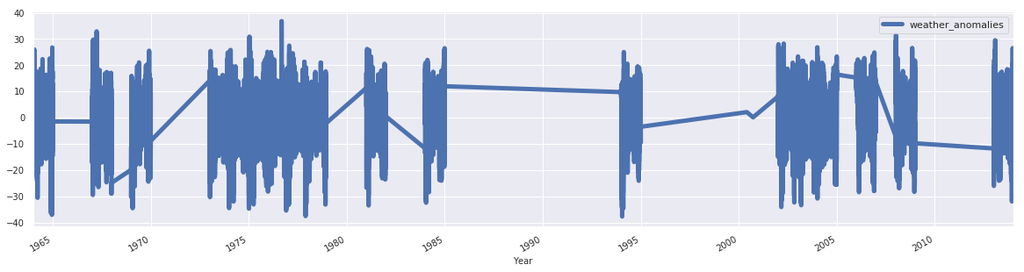

```python
df_anow =df[['weather_anomalies']]
df_anow.rolling(12).mean().plot(figsize=(20,5),linewidth = 5,fontsize = 10)
plt.xlabel('Year',fontsize = 10);
```

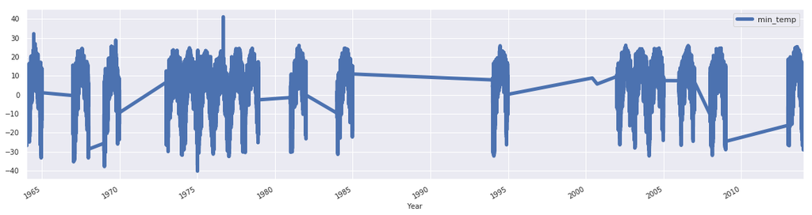

```python
df_min =df[['min_temp']]
df_min.rolling(12).mean().plot(figsize=(20,5),linewidth = 5,fontsize = 10)
plt.xlabel('Year',fontsize = 10);
```

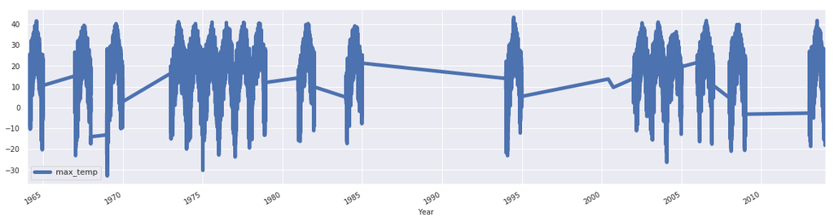

```python
df_max =df[['max_temp']]
df_max.rolling(12).mean().plot(figsize=(20,5),linewidth = 5,fontsize = 10)
plt.xlabel('Year',fontsize = 10);
```

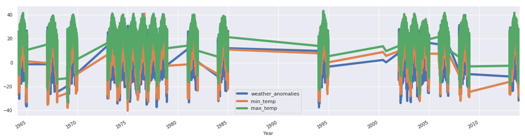

```python
df_c = pd.concat([df_anow.rolling(12).mean(),df_min.rolling(12).mean(),df_max.rolling(12).mean()],axis =1 )
df_c.plot(figsize =(20,5),linewidth = 5, fontsize = 10 )
plt.xlabel('Year',fontsize = 10);
```

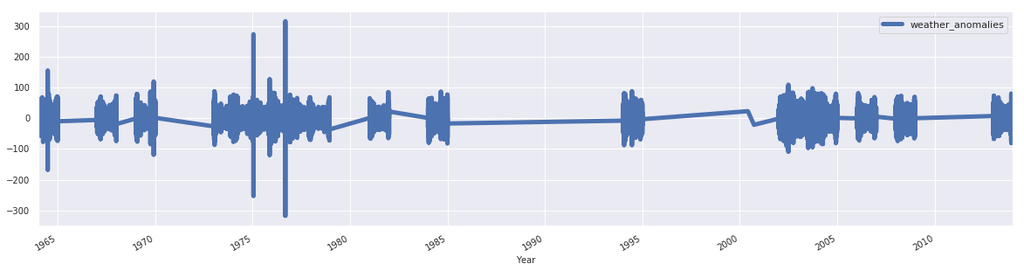

```python
df_anow.diff().plot(figsize =(20,5), linewidth = 5, fontsize = 10 )
plt.xlabel('Year', fontsize = 10);
```

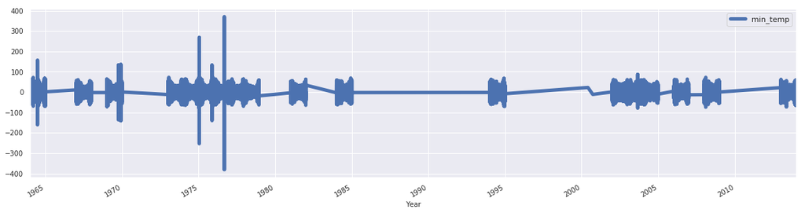

```python
df_min.diff().plot(figsize =(20,5), linewidth = 5, fontsize = 10 )
plt.xlabel('Year', fontsize = 10);
```

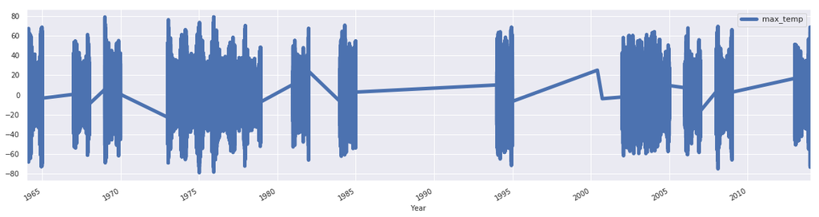

```python
df_max.diff().plot(figsize =(20,5), linewidth = 5, fontsize = 10 )
plt.xlabel('Year', fontsize = 10);
```

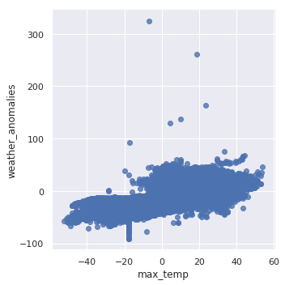

```python
sns.lmplot(x ='max_temp', y = 'weather_anomalies', fit_reg = False, data = df);
```

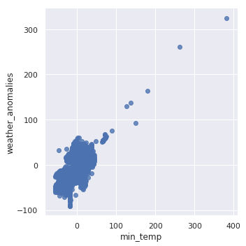

```python
sns.lmplot(x ='min_temp', y = 'weather_anomalies', fit_reg = False, data = df);
```

#### Inferential Statistics: Regression Analysis

Regression partA:Using average_temp as the independent variable/predictor, which is the mean of min_temp and max_temp and weather _anomalies as dependent variable/predictate

```python
X1 = df[['average_temp']]
Y = df['weather_anomalies']
```

```python
from sklearn.linear_model import LinearRegression
import statsmodels.formula.api as sm
lr= LinearRegression()
lr.fit(X1,Y)
print(lr.intercept_)
print(lr.coef_)
regressor_OLS = sm.OLS(endog = Y, exog = X1 ).fit()
regressor_OLS.summary()
```

```
-8.370816497809532
[0.69038322]
```

OLS Regression Results

| Dep. Variable: | weather_anomalies | R-squared: | 0.241 |
| --- | --- | --- | --- |
| Model: | OLS | Adj. R-squared: | 0.241 |
| Method: | Least Squares | F-statistic: | 3.326e+05 |
| Date: | Fri, 06 Dec 2019 | Prob (F-statistic): | 0.00 |
| Time: | 14:11:54 | Log-Likelihood: | -4.1180e+06 |
| No. Observations: | 1048575 | AIC: | 8.236e+06 |
| Df Residuals: | 1048574 | BIC: | 8.236e+06 |
| Df Model: | 1 |  |  |
| Covariance Type: | nonrobust |  |  |

|  | coef | std err | t | P>\|t\| | [0.025 | 0.975] |
| --- | --- | --- | --- | --- | --- | --- |
| average_temp | 0.3829 | 0.001 | 576.750 | 0.000 | 0.382 | 0.384 |

| Omnibus: | 9899.697 | Durbin-Watson: | 0.630 |
| --- | --- | --- | --- |
| Prob(Omnibus): | 0.000 | Jarque-Bera (JB): | 11414.530 |
| Skew: | 0.188 | Prob(JB): | 0.00 |
| Kurtosis: | 3.347 | Cond. No. | 1.00 |

Warnings:  
[1] Standard Errors assume that the covariance matrix of the errors is correctly specified.

Since Adj. R-squared = 0.241 and Prob (F-statistic)=0.00, which is less than 0.05, there is a slight signifance relationship between average temperature and weather anomalies

Regression partB:Using max_temp and min_temp as the independent variable/predictorand weather _anomalies as dependent variable/predictate

```python
X2 = df[['max_temp','min_temp']]
Y = df['weather_anomalies']
```

```python
from sklearn.linear_model import LinearRegression
import statsmodels.formula.api as sm
lr= LinearRegression()
lr.fit(X2, Y)
print(lr.intercept_)
print(lr.coef_)
regressor_OLS = sm.OLS(endog = Y, exog = X2).fit()
regressor_OLS.summary()
```

```
-10.006794624267764
[0.47258544 0.21212434]
```

OLS Regression Results

| Dep. Variable: | weather_anomalies | R-squared: | 0.347 |
| --- | --- | --- | --- |
| Model: | OLS | Adj. R-squared: | 0.347 |
| Method: | Least Squares | F-statistic: | 2.789e+05 |
| Date: | Fri, 06 Dec 2019 | Prob (F-statistic): | 0.00 |
| Time: | 10:15:56 | Log-Likelihood: | -4.0389e+06 |
| No. Observations: | 1048575 | AIC: | 8.078e+06 |
| Df Residuals: | 1048573 | BIC: | 8.078e+06 |
| Df Model: | 2 |  |  |
| Covariance Type: | nonrobust |  |  |

|  | coef | std err | t | P>\|t\| | [0.025 | 0.975] |
| --- | --- | --- | --- | --- | --- | --- |
| max_temp | -0.1067 | 0.001 | -136.033 | 0.000 | -0.108 | -0.105 |
| min_temp | 0.6910 | 0.001 | 554.146 | 0.000 | 0.689 | 0.693 |

| Omnibus: | 12945.828 | Durbin-Watson: | 0.771 |
| --- | --- | --- | --- |
| Prob(Omnibus): | 0.000 | Jarque-Bera (JB): | 13405.884 |
| Skew: | 0.275 | Prob(JB): | 0.00 |
| Kurtosis: | 2.936 | Cond. No. | 3.35 |

Warnings:  
[1] Standard Errors assume that the covariance matrix of the errors is correctly specified.

Since Adj. R-squared = 0.347 and Prob (F-statistic)=0.00, which is less than 0.05, there is a moderate signifance relationship between min and max temperature and weather anomalies. There is also an improvement in the model as compared to the one above that used average of min and max temperature.

Regression partC:Using max_temp, min_temp ,weather_category_numeri and as the independent variable/predictorand weather _anomalies as dependent variable/predictate

```python
X3 = df[['max_temp','min_temp','weather_category_numeric']]
Y = df['weather_anomalies']
```

```python
from sklearn.linear_model import LinearRegression
import statsmodels.formula.api as sm
lr= LinearRegression()
lr.fit(X3, Y )
print(lr.intercept_)
print(lr.coef_)
regressor_OLS = sm.OLS(endog = Y, exog = X3).fit()
regressor_OLS.summary()
```

```
-6.00647424180073
[ 0.4376976   0.20787949 -1.95897231]
```

OLS Regression Results

| Dep. Variable: | weather_anomalies | R-squared: | 0.439 |
| --- | --- | --- | --- |
| Model: | OLS | Adj. R-squared: | 0.439 |
| Method: | Least Squares | F-statistic: | 2.732e+05 |
| Date: | Fri, 06 Dec 2019 | Prob (F-statistic): | 0.00 |
| Time: | 14:12:20 | Log-Likelihood: | -3.9597e+06 |
| No. Observations: | 1048575 | AIC: | 7.919e+06 |
| Df Residuals: | 1048572 | BIC: | 7.919e+06 |
| Df Model: | 3 |  |  |
| Covariance Type: | nonrobust |  |  |

|  | coef | std err | t | P>\|t\| | [0.025 | 0.975] |
| --- | --- | --- | --- | --- | --- | --- |
| max_temp | 0.2555 | 0.001 | 224.490 | 0.000 | 0.253 | 0.258 |
| min_temp | 0.3306 | 0.001 | 228.363 | 0.000 | 0.328 | 0.333 |
| weather_category_numeric | -3.6077 | 0.009 | -413.550 | 0.000 | -3.625 | -3.591 |

| Omnibus: | 218639.596 | Durbin-Watson: | 0.883 |
| --- | --- | --- | --- |
| Prob(Omnibus): | 0.000 | Jarque-Bera (JB): | 501231.133 |
| Skew: | 1.187 | Prob(JB): | 0.00 |
| Kurtosis: | 5.415 | Cond. No. | 22.6 |

Warnings:  
[1] Standard Errors assume that the covariance matrix of the errors is correctly specified.

Since Adj. R-squared = 0.439 and Prob (F-statistic)=0.00, which is less than 0.05, there is a signifance relationship between min and max temperature,weather caterogies and weather anomalies. There is also an improvement in the model as compared to the one above that used average of min and max temperature.This is therefore better than the first two models above

#### Inferential Statistics: Analysis of Variance(ANOVA)¶

Anova Analysis aims to determine wheather there is a signficant difference between different weather categories. In other words being able to determine if the averages weather anomalies of Weak Hot,Strong Hot,Weak Cold and Strong Cold are significantly different

```python
import statsmodels.api as sm
from statsmodels.formula.api import ols
ANOVA_results = ols('df["weather_anomalies"]~ C(df["weather_category"])', data=df).fit()
print(ANOVA_results.summary())
anova_table = sm.stats.anova_lm(ANOVA_results,type =2)
print(anova_table)
```

```
                               OLS Regression Results
===================================================================================
Dep. Variable:     df["weather_anomalies"]   R-squared:                       0.910
Model:                                 OLS   Adj. R-squared:                  0.910
Method:                      Least Squares   F-statistic:                 3.516e+06
Date:                     Fri, 06 Dec 2019   Prob (F-statistic):               0.00
Time:                             14:12:34   Log-Likelihood:            -3.0025e+06
No. Observations:                  1048575   AIC:                         6.005e+06
Df Residuals:                      1048571   BIC:                         6.005e+06
Df Model:                                3
Covariance Type:                 nonrobust
===========================================================================================================
                                              coef    std err          t      P>|t|      [0.025      0.975]
-----------------------------------------------------------------------------------------------------------
Intercept                                 -28.8058      0.017  -1714.898      0.000     -28.839     -28.773
C(df["weather_category"])[T.Strong Hot]    51.7088      0.024   2171.629      0.000      51.662      51.755
C(df["weather_category"])[T.Weak Cold]     17.4753      0.018    969.054      0.000      17.440      17.511
C(df["weather_category"])[T.Weak Hot]      38.7665      0.018   2174.631      0.000      38.732      38.801
==============================================================================
Omnibus:                   397080.140   Durbin-Watson:                   1.400
Prob(Omnibus):                  0.000   Jarque-Bera (JB):        136416616.807
Skew:                           0.509   Prob(JB):                         0.00
Kurtosis:                      58.869   Cond. No.                         10.1
==============================================================================

Warnings:
[1] Standard Errors assume that the covariance matrix of the errors is correctly specified.
                                  df        sum_sq       mean_sq  \
C(df["weather_category"])        3.0  1.895772e+08  6.319241e+07
Residual                   1048571.0  1.884600e+07  1.797303e+01

                                      F  PR(>F)
C(df["weather_category"])  3.515958e+06     0.0
Residual                            NaN     NaN
```

Since the p value is 0.0 which is less than 0.05 there weather categories are significantly different

#### Machine Learning: Supervised: Regression

```python
from sklearn import linear_model
from sklearn.metrics import mean_squared_error, r2_score
from sklearn.model_selection import train_test_split
X1_train,X1_test,Y_train,Y_test = train_test_split(X1,Y, test_size = 0.25 , random_state = 0)
regressor = linear_model.LinearRegression()
model_fit= regressor.fit(X1_train,Y_train)
Y_predicted = regressor.predict(X1_train)
mse = mean_squared_error(Y_train,Y_predicted)
r2 = r2_score(Y_train,Y_predicted)
print(r2)
print(Y_predicted)
print(mse)
```

```
0.43822145138539137
[  5.44407533 -24.50326927  -7.23259765 ...   1.40273817   9.45087114
 -17.59500062]
111.84756330269866
```

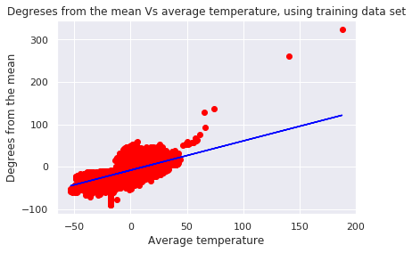

```python
visual_train = plt
visual_train.scatter(X1_train,Y_train,color = 'red')
visual_train.plot(X1_train, regressor.predict(X1_train), color = 'blue')
visual_train.title('Degreses from the mean Vs average temperature, using training data set')
visual_train.xlabel('Average temperature')
visual_train.ylabel('Degrees from the mean')
visual_train.show()
```

```python
from sklearn import linear_model
from sklearn.metrics import mean_squared_error, r2_score
from sklearn.model_selection import train_test_split
X2_train,X2_test,Y_train,Y_test = train_test_split(X2,Y, test_size = 0.25 , random_state = 0)
regressor = linear_model.LinearRegression()
model_fit= regressor.fit(X2_train,Y_train)
Y_predicted = regressor.predict(X2_train)
mse = mean_squared_error(Y_train,Y_predicted)
r2 = r2_score(Y_train,Y_predicted)
print(r2)
print(Y_predicted)
print(mse)
```

```
0.4420260785782081
[  4.84079644 -25.13546925  -6.41769955 ...   1.20993571   9.90830907
 -18.5699589 ]
111.09007926945968
```

```python
from sklearn import linear_model
from sklearn.metrics import mean_squared_error, r2_score
from sklearn.model_selection import train_test_split
X3_train,X3_test,Y_train,Y_test = train_test_split(X3,Y, test_size = 0.25 , random_state = 0)
regressor = linear_model.LinearRegression()
model_fit= regressor.fit(X3_train,Y_train)
Y_predicted = regressor.predict(X3_train)
mse = mean_squared_error(Y_train,Y_predicted)
r2 = r2_score(Y_train,Y_predicted)
print(r2)
print(Y_predicted)
print(mse)
```

```
0.4538344124306918
[  5.96363169 -24.24223368  -4.7344563  ...   0.56182112  10.67492897
 -18.03316566]
108.73909350946208
```

#### Machine Learning: Supervised: Classification:Support Vector Machine

SVM is used to predict new weather class labels

```python
df_svm = df[['weather_anomalies','max_temp','min_temp','weather_category_numeric']]
```

```python
df_svm.head()
```

| period | weather_anomalies | max_temp | min_temp | weather_category_numeric |
| --- | --- | --- | --- | --- |
| 2013-12-31 | -26.16 | -12.2 | -22.8 | 3 |
| 2013-12-31 | -15.28 | -18.2 | -26.0 | 2 |
| 2013-12-31 | -32.28 | -17.8 | -27.8 | 3 |
| 2013-12-31 | -32.47 | -17.2 | -24.4 | 3 |
| 2013-12-31 | -31.52 | -19.4 | -29.4 | 3 |

Bescause support Vector Machine Algorithm is somehow slow on very large data sets like this one, it is rational and important to sample for modelling.

```python
dfclass = df_svm.sample(n = 10000) # Random selection of 10000 records for SVM modelling as shown in the dfclass created below.
dfclass.head()
```

| period | weather_anomalies | max_temp | min_temp | weather_category_numeric |
| --- | --- | --- | --- | --- |
| 2002-01-23 | 13.02 | 9.4 | 0.6 | 1 |
| 1981-11-02 | 12.69 | 23.3 | 6.1 | 1 |
| 1977-06-11 | 6.20 | 35.6 | 22.8 | 1 |
| 2013-01-13 | -10.81 | 3.3 | -7.8 | 2 |
| 2004-08-21 | -9.05 | 23.9 | 3.3 | 2 |

```python
X_svm = dfclass[['weather_anomalies','max_temp','min_temp']] # creating the feature set for predictingd or set of independent variables
Y_svm = dfclass['weather_category_numeric'] #  creating the label class variable or dependent variable.
```

#### Appling SVM to X_svm and Y_svm for prediction

```python
from sklearn.model_selection import train_test_split
X_svm_train, X_svm_test, Y_svm_train, Y_svm_test = train_test_split(X_svm, Y_svm, test_size = 0.20)
from sklearn.svm import SVC
svclassifier = SVC(kernel='linear')
svclassifier.fit(X_svm_train, Y_svm_train)
y_pred = svclassifier.predict(X_svm_test)
from sklearn.metrics import classification_report, confusion_matrix
print(confusion_matrix(Y_svm_test,y_pred))
print(classification_report(Y_svm_test,y_pred))
```

```
[[915   0   0  14]
 [  0 790   6   0]
 [  0  12 127   0]
 [ 18   0   0 118]]
              precision    recall  f1-score   support

           1       0.98      0.98      0.98       929
           2       0.99      0.99      0.99       796
           3       0.95      0.91      0.93       139
           4       0.89      0.87      0.88       136

   micro avg       0.97      0.97      0.97      2000
   macro avg       0.95      0.94      0.95      2000
weighted avg       0.97      0.97      0.97      2000
```